# Cyclistic Bike-Share trip data

### 5. Finding the total of ‘member’ riders and ‘casual’ riders:

- Total riders:

```r
bikeshare_tripdata %>%
  summarise(n_riders = n_distinct(ride_id))
```

```
## # A tibble: 1 × 1
##   n_riders
##      <int>
## 1   503421
```

- There are a total of **503,421** riders for the first quarter of 2022.
- Total riders(**member/casual**):

```r
bikeshare_tripdata %>%
  group_by(member_casual) %>%
  summarise(n_riders = n_distinct(ride_id))
```

```
## # A tibble: 2 × 2
##   member_casual n_riders
##   <chr>            <int>
## 1 casual          129818
## 2 member          373603
```

- There are **129,818** **casual riders**, and **373,603** **member riders**.

**Plot** to show analysis:

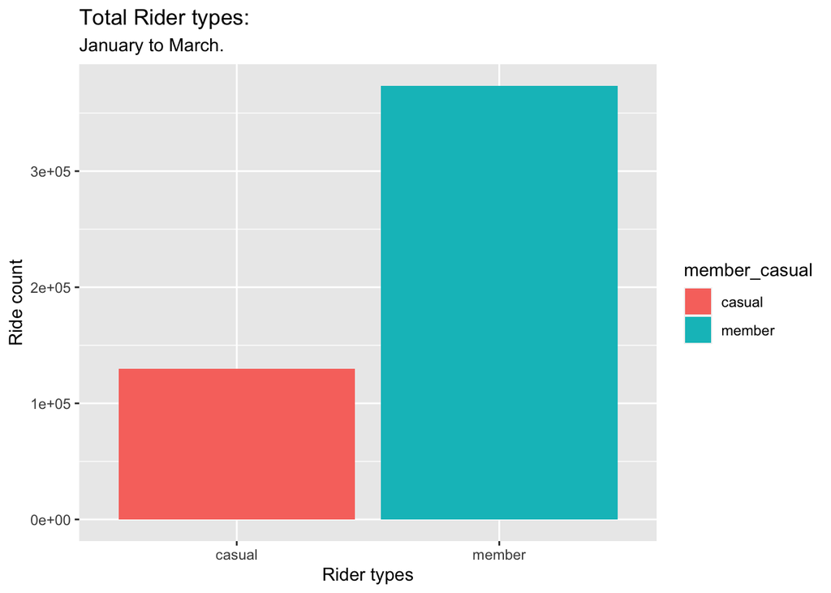

```r
ggplot(data = bikeshare_tripdata) +
  geom_bar(mapping = aes(x = member_casual, fill = member_casual)) +
  labs(x = "Rider types", y = "Ride count", title = "Total Rider types:", subtitle = "January to March.")
```

This plot shows that there are more *‘member’* riders than *‘casual’* riders.

### 6. Finding the growth rate of riders in the first quarter of 2022:

- First extract **month** from the **‘started_at’** column:

```r
bikeshare_tripdata <- bikeshare_tripdata %>%
  mutate(ride_months = month(started_at))
```

- Now, get the number of **member** and **casual** riders for each month:

```r
bikeshare_tripdata %>%
  group_by(member_casual) %>%
  filter(ride_months == 1) %>%
  drop_na() %>%
  count()
```

```
## # A tibble: 2 × 2
## # Groups:   member_casual [2]
##   member_casual     n
##   <chr>         <int>
## 1 casual        12605
## 2 member        67523
```

```r
bikeshare_tripdata %>%
  group_by(member_casual) %>%
  filter(ride_months == 2) %>%
  drop_na() %>%
  count()
```

```
## # A tibble: 2 × 2
## # Groups:   member_casual [2]
##   member_casual     n
##   <chr>         <int>
## 1 casual        15144
## 2 member        74034
```

```r
bikeshare_tripdata %>%
  group_by(member_casual) %>%
  filter(ride_months == 3) %>%
  drop_na() %>%
  count()
```

```
## # A tibble: 2 × 2
## # Groups:   member_casual [2]
##   member_casual      n
##   <chr>          <int>
## 1 casual         67156
## 2 member        148827
```

**Plot** to show analysis:

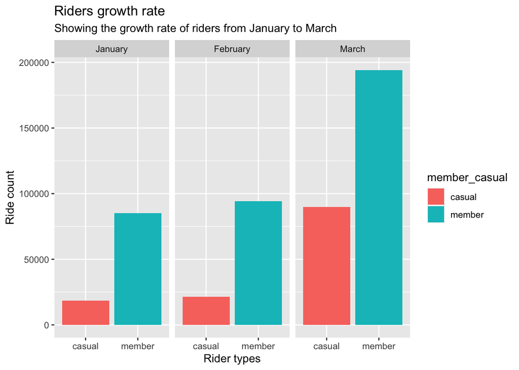

```r
ggplot(data = bikeshare_tripdata) +
  geom_bar(mapping = aes(x = member_casual, fill = member_casual)) +
  facet_wrap(~ride_months, labeller = labeller(ride_months = c("1" = "January", "2" = "February", "3" = "March"))) +
  labs(title = "Riders growth rate", subtitle = "Showing the growth rate of riders from January to March", x = "Rider types", y = "Ride count")
```

- This analysis shows just little growth in the **member** and **casual** riders between **January and February**, and a notable growth in the month of **March**.

### 7. Finding the ride length of rides:

- First created a new column ‘ride_length’ by subtracting **‘started_at’** column from **‘ended_at’** column to get the ride length.

```r
bikeshare_tripdata <- mutate(bikeshare_tripdata, ride_length = ended_at - started_at)
```

- The results were in seconds. Next step is to convert seconds to minutes:

```r
bikeshare_tripdata <- bikeshare_tripdata %>%
  mutate(ride_length_min = as.numeric(ride_length) / 60)
```

- Noticing that the minute values that are difficult to read, the next step is to convert the **‘ride_length_min’** from **minutes** to **hours**.

```r
bikeshare_tripdata <- bikeshare_tripdata %>%
  mutate(ride_length_hour = as.numeric(ride_length_min)/ 60)
```

- Arrange the ‘ride_length_hour’ in descending order to see the **longest ride duration**:

```r
bikeshare_tripdata %>%
  arrange(-ride_length_hour)
```

```
## # A tibble: 503,421 × 19
##    Source ride_id          rideable_type started_at          ended_at
##    <chr>  <chr>            <chr>         <dttm>              <dttm>
##  1 3      23697816035F9A8F docked_bike   2022-03-05 19:08:58 2022-03-29 15:43:02
##  2 1      578BA30BA1348F18 docked_bike   2022-01-01 01:00:05 2022-01-21 08:51:11
##  3 1      5EE2D7C533CCC17B docked_bike   2022-01-06 19:07:45 2022-01-25 14:30:33
##  4 1      5679434466A48868 docked_bike   2022-01-01 01:23:25 2022-01-19 10:02:17
##  5 3      C47BA0F4BF8E591A docked_bike   2022-03-17 17:45:35 2022-03-27 21:36:36
##  6 3      ACBFC7A83205A6DA docked_bike   2022-03-17 17:45:29 2022-03-27 21:36:23
##  7 1      5AA216F2E2138811 docked_bike   2022-01-13 17:44:13 2022-01-23 15:02:19
##  8 3      6ED649F580DA1104 docked_bike   2022-03-23 06:01:59 2022-04-01 22:10:12
##  9 3      AFEBAE66300B7ACF docked_bike   2022-03-11 17:35:10 2022-03-20 21:31:16
## 10 3      BD2DD70F34654B49 docked_bike   2022-03-22 23:59:46 2022-03-31 21:03:48
## # ℹ 503,411 more rows
## # ℹ 14 more variables: start_station_name <chr>, start_station_id <chr>,
## #   end_station_name <chr>, end_station_id <chr>, start_lat <dbl>,
## #   start_lng <dbl>, end_lat <dbl>, end_lng <dbl>, member_casual <chr>,
## #   day_of_week <chr>, ride_months <dbl>, ride_length <drtn>,
## #   ride_length_min <dbl>, ride_length_hour <dbl>
```

- Arranging the ‘ride_length_hour’ in descending order, it is seen in the first rows that the **casual** riders spend more time riding that **member** riders.

**Lets test the hypothesis**:

- Get the sum of ride length in hours my having a sum of the **ride_length_hour** column and grouping by **casual** and **member** riders:

```r
bikeshare_tripdata %>%
  group_by(member_casual) %>%
  drop_na() %>%
  summarise(sum_ride_length_hour = sum(ride_length_hour))
```

```
## # A tibble: 2 × 2
##   member_casual sum_ride_length_hour
##   <chr>                        <dbl>
## 1 casual                      43840.
## 2 member                      53953.
```

- **Plot** to show analysis:

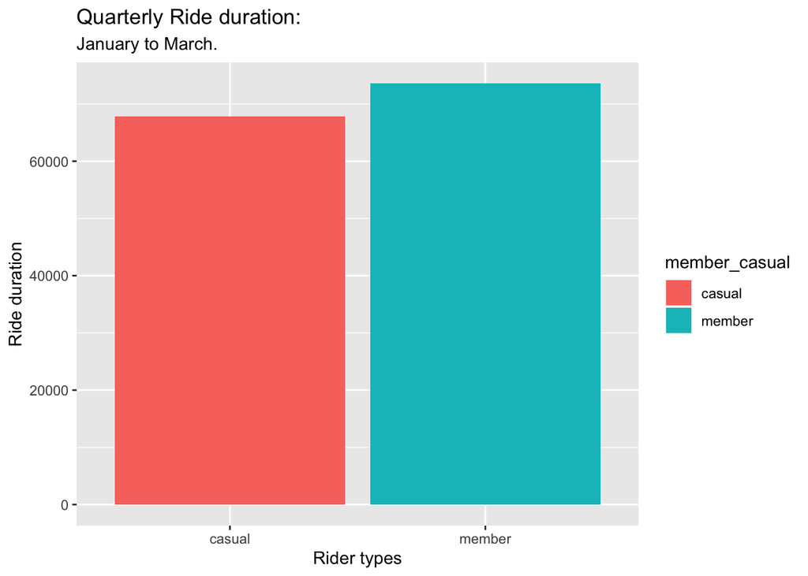

```r
ggplot(data = bikeshare_tripdata) +
  geom_col(mapping = aes(y = ride_length_hour, x = member_casual, fill = member_casual)) +
  labs(x = "Rider types", y = "Ride duration", title = "Quarterly Ride duration:", subtitle = "January to March.")
```

- The result shows the **member** riders have more **ride duration** than the **casual** riders.
- Test the hypothesis further by getting **ride duration** for each month:

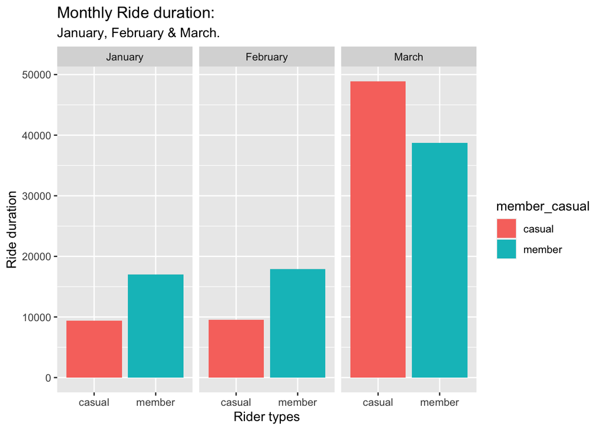

```r
ggplot(data = bikeshare_tripdata) +
  geom_col(mapping = aes(y = ride_length_hour, x = member_casual, fill = member_casual)) +
  facet_wrap(~ride_months, labeller = labeller(ride_months = c("1" = "January", "2" = "February", "3" = "March"))) +
  labs(x = "Rider types", y = "Ride duration", title = "Monthly Ride duration:", subtitle = "January, February & March.")
```

- This plot shows that my hypothesis is partly correct. The **casual** riders had the longest ride duration for **March**.

### 8. Finding the **Bike types** used by both **member** and **casual** riders:

- This analysis was conducted using a simple **bar plot**:

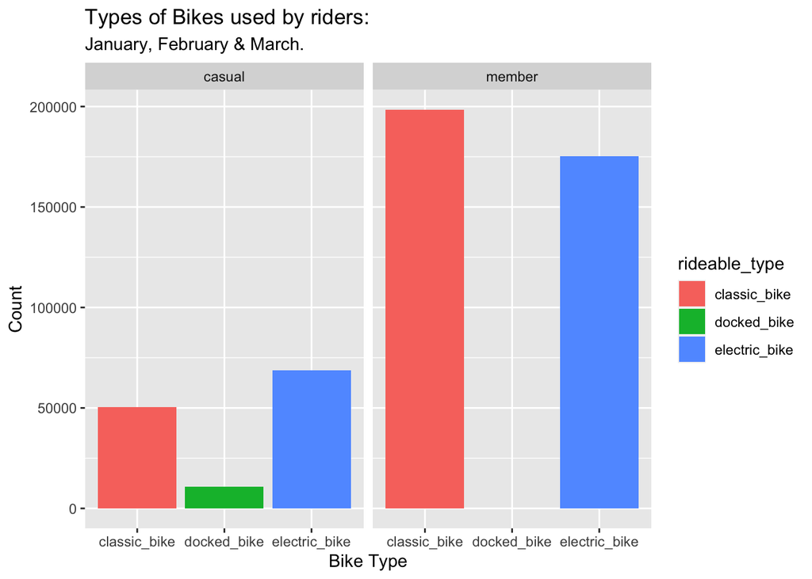

```r
ggplot(data = bikeshare_tripdata) +
  geom_bar(mapping = aes(x = rideable_type, fill = rideable_type)) +
  facet_wrap(~member_casual) +
  labs(x = "Bike Type", y = "Count", title = "Types of Bikes used by riders:", subtitle = "January, February & March.")
```

- This plot shows the **bike type** distribution among **member** and **casual** riders, showing that **member** riders use **classic bikes** than **electric bikes** with no single usage of **docked bikes**, and **casual** riders use all the **bike types** with the data showing **electric bikes** are mostly used.

### Conclusion:

1. There are **503,421** total riders from **January to March**, with **129,818** as **casual riders** and **373,603** as **member riders**.
2. **Member riders** use Bike-Share mostly on **weekdays** and **Casual riders** use Bike-Share more on **weekends**.
3. There was a significant increase in the **riders** growth in the month of **March**.
4. For the month of **March**, **casual** riders had more **ride length** than **member** riders.
5. **Member** riders only use **classic** and **electric** bikes and **casual** riders use all three bike types with **docked** bikes being the least used.

### Recommendation:

1. There should be more provision of **classic** and **electric** bikes, following their usage by **member** riders. It is possible that the **casual** use **docked** bikes because they had no other options.
2. Continue media promotion. Following the growth spike in **March**, it is likely that those results were achieved because of the social media promotion.
3. Further analysis of **member** and **casual** rider behavour for the next quarter of 2022.

**Thank you!**